# scRNA-seq Preprocessing and Quality Control

Stephanie Hickey

2022-09-09

#### Project: Day17_Reprogramming_scRNA_seq

#### Lab: Ralston

## Set up

### Make project directories

```r
project.dir = paste0(params$working_dir, params$project_name)
if(!dir.exists(project.dir)){dir.create(project.dir)}

data.dir = paste0(project.dir, "/data")
if(!dir.exists(data.dir)){dir.create(data.dir)}

results.dir = paste0(project.dir, "/results")
if(!dir.exists(results.dir)){dir.create(results.dir)}
```

### Set seed and root directory

```r
knitr::opts_knit$set(root.dir = params$working_dir)
set.seed(1)
```

### Load the necessary libraries

```r
library(tidyverse)
library(Seurat)
library(patchwork)
library(clustree)
library(filesstrings)
library(Matrix)
```

## QC filtering

### Create the Seurat object

Filter for genes expressed in at least 1 cell.

```r
# read in the filtered barcode matrix
cr.data = Read10X(data.dir = params$raw_data_dir)

# make the Seurat object
seuratOb = CreateSeuratObject(cr.data,
                              project = params$project_name,
                              assay = "RNA",
                              min.cells = 1)
seuratOb
```

```
## An object of class Seurat
## 22405 features across 5395 samples within 1 assay
## Active assay: RNA (22405 features, 0 variable features)
```

### Pre-filtering QC violin plots

Violin plots show the distribution of

- The number of genes (features) detected per cell
- The number of UMI counts detected per cell
- The percent of mitochondrial gene counts as a fraction of all of the counts in the cell
  - High mitochondrial gene counts suggest that the cell ruptured before the cell was captured in the GEM, indicating a low quality transcriptome.

In the plots below, each dot is a cell, and we can use these plots to visually identify cutoff ranges

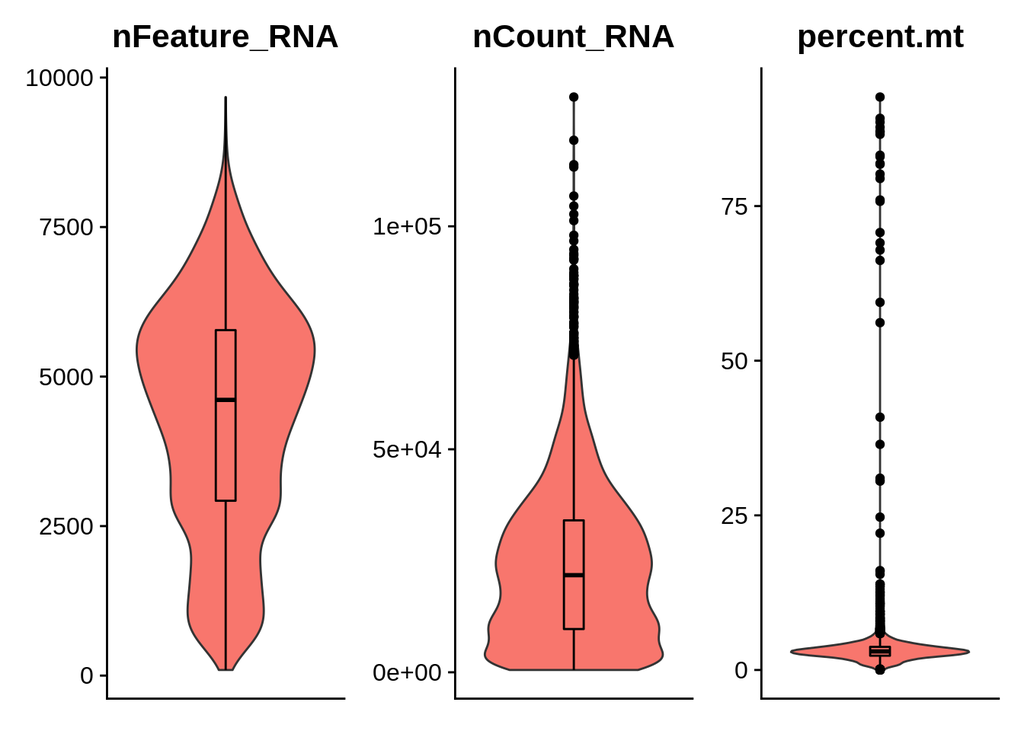

```r
# add percent counts from mitochondrial genes for each cell
seuratOb[["percent.mt"]] <- PercentageFeatureSet(seuratOb, pattern = "^mt-")

#plot qc violins

plots = VlnPlot(seuratOb,
                features = c("nFeature_RNA",
                             "nCount_RNA",
                             "percent.mt"),
                pt.size = 0,
                ncol = 3,
                combine = FALSE)

for(i in 1:length(plots)) {
  plots[[i]] =
    plots[[i]] +
    geom_boxplot(width=0.1, color="black") +
    theme(legend.position = 'none',
          axis.title.x=element_blank(),
          axis.text.x=element_blank(),
          axis.ticks.x=element_blank())
  }

Pall = plots[[1]] + plots[[2]] + plots[[3]]

# save qc violins
ggsave(Pall,
       file = paste0(results.dir, "/QC_vln_", params$project_name, ".pdf"),
       width = 6,
       height = 4)

# print qc violins
Pall
```

- Median genes expressed per cell = 4610
- Median UMI per cell = 2.177410^{4}
- Median percent mitochondrial reads = 2.9993669

### QC filtering plots

```r
pMlo = as.numeric(params$pMlo)
pMhi = as.numeric(params$pMhi)
nFeatureHi = as.numeric(params$nFeatureHi)
nFeatureLo = as.numeric(params$nFeatureLo)
nCountLo = as.numeric(params$nCountLo)
nCountHi = as.numeric(params$nCountHi)
```

Filtering for cells with fewer than 5%-10% of the reads coming from mitochondrial genes is pretty standard. So we'll stick with that.

- pMlo = -Inf
- pMhi = 10

The prelim clustering from cellranger indicates that the cells are being grouped mainly by nCounts. Specifically there's a distinct cluster of cells in each run with fewer than 5000 UMI.

- nCountLo = 5000
- nCountHi = Inf

- nFeatureHi = Inf
- nFeatureLo = 1000

```r
# plot nCount_RNA vs percent.mt
plot1 <- FeatureScatter(seuratOb,
                        feature1 = "nCount_RNA",
                        feature2 = "percent.mt") +
  annotate("rect",
           xmin = -Inf,
           xmax = Inf,
           ymin = pMlo,
           ymax = pMhi,
           alpha = 0.1,
           fill = "green") +
  annotate("rect",
           xmin = nCountLo,
           xmax = nCountHi,
           ymin = -Inf,
           ymax = Inf,
           alpha = 0.1,
           fill = "blue") +
  theme(legend.position="none")

# plot nCount_RNA vs nFeature_RNA
plot2 <- FeatureScatter(seuratOb,
                        feature1 = "nCount_RNA",
                        feature2 = "nFeature_RNA") +
  annotate("rect",
           xmin = -Inf,
           xmax = Inf,
           ymin = nFeatureLo,
           ymax = nFeatureHi,
           alpha = 0.1,
           fill = "green") +
  annotate("rect",
           xmin = nCountLo,
           xmax = nCountHi,
           ymin = -Inf,
           ymax = Inf,
           alpha = 0.1,
           fill = "blue") +
  theme(legend.position="none")

# save the plots
pdf(file = paste0(results.dir, "/QC_scatter_", params$project_name ,".pdf"),
    width = 10,
    height = 4)
plot1 + plot2
dev.off()
```

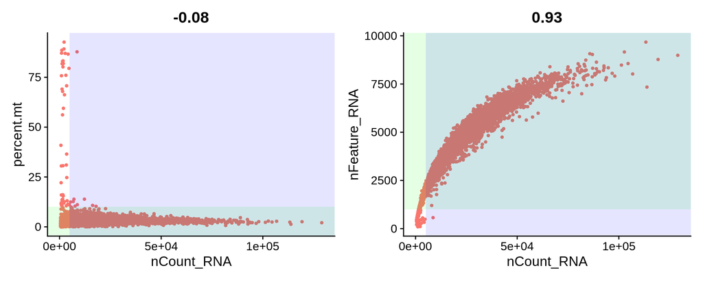

```r
# print the plots
plot1 + plot2
```

Check how many cells we would have after filtering

```r
check = seuratOb@meta.data %>%
  filter(percent.mt < pMhi,
         nFeature_RNA > nFeatureLo,
         nCount_RNA > nCountLo)
```

We started with 5395 cells. Filter for high-quality cells based on the above criteria.

```r
seuratOb <- subset(seuratOb,
                   subset = nFeature_RNA > nFeatureLo &
                            nCount_RNA > nCountLo &
                            percent.mt < pMhi)
```

After filtering we have 4570 high-quality cells. These cells are shaded by both blue and green in the plots above. These cutoffs are not set in stone. We can be as strict or lenient as you would like. The ultimate test is if the clusters ultimately produced by the cells are biologically relevant. Often, low quality cells form their own, meaningless, cluster.

- Median genes expressed per cell after filtering = 4990
- Median UMI per cell after filtering = 2.521110^{4}
- Median percent mitochondrial reads after filtering = 3.0760113

### Save the Seurat Object

```r
save(seuratOb,  file = paste0(data.dir, "/", params$project_name, "_QC_filtered_SeuratObject.Rdata"))
```

Saved here: `/mnt/ufs18/home-115/hickeys6/Documents/Ralston/projects/Day17_Reprogramming_scRNA_seq/data/Day17_Reprogramming_scRNA_seq_QC_filtered_SeuratObject.Rdata`